# vinit-notebook-1

```python
import os
from scipy.io import loadmat
import dataExtract_latest
from sklearn.model_selection import train_test_split
from sklearn import svm
from sklearn import metrics
import numpy as np
import matplotlib.pyplot as plt
import pandas as pd
```

```python
subjects = [['04799'],['04820'],['04847'],['05675'],['05680'],['05710']]
```

Load mat files of subjects using lodmat fucntion of scipy

```python
mat04799  = loadmat('/Users/vinitsheth/SmlFinalProject/Data/data-starplus-04799-v7.mat')
mat04820  = loadmat('/Users/vinitsheth/SmlFinalProject/Data/data-starplus-04820-v7.mat')
mat04847  = loadmat('/Users/vinitsheth/SmlFinalProject/Data/data-starplus-04847-v7.mat')
mat05675  = loadmat('/Users/vinitsheth/SmlFinalProject/Data/data-starplus-05675-v7.mat')
mat05680  = loadmat('/Users/vinitsheth/SmlFinalProject/Data/data-starplus-05680-v7.mat')
mat05710  = loadmat('/Users/vinitsheth/SmlFinalProject/Data/data-starplus-05710-v7.mat')
```

Load meta of each subjects

```python
mata04799 = dataExtract_latest.getMeta(mat04799)
mata04820 = dataExtract_latest.getMeta(mat04820)
mata04847 = dataExtract_latest.getMeta(mat04847)
mata05675 = dataExtract_latest.getMeta(mat05675)
mata05680 = dataExtract_latest.getMeta(mat05680)
mata05710 = dataExtract_latest.getMeta(mat05710)
```

subject 04799.

generate Info for each trial.

Extract sentence data and picture data where cond is 2 or 3 for subject 04799.

choose 0 to 15 for fist stimulus choose 16 to 31 for second stimulus

First stimulus is shown for 4 seconds and 1 image is taken every 500 ms, But it is believed that effect remains for 8 seconds in voxels so 0 to 15 and 16 to 31 are taken.

Store sentence and pictures differently

```python
info04799 = []
sentence04799 = []
picture04799 = []
rawData04799 = mat04799['data']
for i in range(mata04799['ntrials']):
    infoOfGivenTrial = dataExtract_latest.getInfoFromList(mat04799,i)
    info04799.append(infoOfGivenTrial)
    if infoOfGivenTrial['cond'] == 2 or infoOfGivenTrial['cond'] == 3:
        if infoOfGivenTrial['firstStimulus'] == 'P':
            for j in range(16):
                picture04799.append(rawData04799[i][0][j])
            for j in range(16,32):
                sentence04799.append(rawData04799[i][0][j])
        elif infoOfGivenTrial['firstStimulus'] == 'S':
            for j in range(16):
                sentence04799.append(rawData04799[i][0][j])
            for j in range(16,32):
                picture04799.append(rawData04799[i][0][j])
```

make data variable to store all the data and label variable for storing labels

label 1 for sentence

label 0 for picture

```python
data04799 = sentence04799+picture04799
```

```python
labels04799 = [1]*len(sentence04799) + [0]*len(picture04799)
```

```python
accuracy04799 = []
for i in range(5):
    x_train04799, x_test04799 , y_train04799, y_test04799 = train_test_split(data04799,labels04799,test_size = 0.2)
    clf = svm.SVC(kernel='linear')
    clf.fit(x_train04799, y_train04799)
    y_pred04799 = clf.predict(x_test04799)
    accuracy = metrics.accuracy_score(y_test04799, y_pred04799)
    accuracy04799.append(accuracy)
```

Doing the same procudere for remaining 5 subjects

For Subject 04820

```python
info04820 = []
sentence04820 = []
picture04820 = []
rawData04820 = mat04820['data']
for i in range(mata04820['ntrials']):
    infoOfGivenTrial = dataExtract_latest.getInfoFromList(mat04820,i)
    info04820.append(infoOfGivenTrial)
    if infoOfGivenTrial['cond'] == 2 or infoOfGivenTrial['cond'] == 3:
        if infoOfGivenTrial['firstStimulus'] == 'P':
            for j in range(16):
                picture04820.append(rawData04820[i][0][j])
            for j in range(16,32):
                sentence04820.append(rawData04820[i][0][j])
        elif infoOfGivenTrial['firstStimulus'] == 'S':
            for j in range(16):
                sentence04820.append(rawData04820[i][0][j])
            for j in range(16,32):
                picture04820.append(rawData04820[i][0][j])
```

```python
data04820 = sentence04820+picture04820
labels04820 = [1]*len(sentence04820) + [0]*len(picture04820)
accuracy04820 = []
for i in range(5):
    x_train04820, x_test04820 , y_train04820, y_test04820 = train_test_split(data04820,labels04820,test_size = 0.2)
    clf = svm.SVC(kernel='linear')
    clf.fit(x_train04820, y_train04820)
    y_pred04820 = clf.predict(x_test04820)
    accuracy = metrics.accuracy_score(y_test04820, y_pred04820)
    accuracy04820.append(accuracy)
```

For Subject 04847

```python
info04847 = []
sentence04847 = []
picture04847 = []
rawData04847 = mat04847['data']
for i in range(mata04847['ntrials']):
    infoOfGivenTrial = dataExtract_latest.getInfoFromList(mat04847,i)
    info04847.append(infoOfGivenTrial)
    if infoOfGivenTrial['cond'] == 2 or infoOfGivenTrial['cond'] == 3:
        if infoOfGivenTrial['firstStimulus'] == 'P':
            for j in range(16):
                picture04847.append(rawData04847[i][0][j])
            for j in range(16,32):
                sentence04847.append(rawData04847[i][0][j])
        elif infoOfGivenTrial['firstStimulus'] == 'S':
            for j in range(16):
                sentence04847.append(rawData04847[i][0][j])
            for j in range(16,32):
                picture04847.append(rawData04847[i][0][j])
data04847 = sentence04847+picture04847
labels04847 = [1]*len(sentence04847) + [0]*len(picture04847)
accuracy04847 = []
for i in range(5):
    x_train04847, x_test04847 , y_train04847, y_test04847 = train_test_split(data04847,labels04847,test_size = 0.2)
    clf = svm.SVC(kernel='linear')
    clf.fit(x_train04847, y_train04847)
    y_pred04847 = clf.predict(x_test04847)
    accuracy = metrics.accuracy_score(y_test04847, y_pred04847)
    accuracy04847.append(accuracy)
```

For Subject 05675

```python
info05675 = []
sentence05675 = []
picture05675 = []
rawData05675 = mat05675['data']
for i in range(mata05675['ntrials']):
    infoOfGivenTrial = dataExtract_latest.getInfoFromList(mat05675,i)
    info05675.append(infoOfGivenTrial)
    if infoOfGivenTrial['cond'] == 2 or infoOfGivenTrial['cond'] == 3:
        if infoOfGivenTrial['firstStimulus'] == 'P':
            for j in range(16):
                picture05675.append(rawData05675[i][0][j])
            for j in range(16,32):
                sentence05675.append(rawData05675[i][0][j])
        elif infoOfGivenTrial['firstStimulus'] == 'S':
            for j in range(16):
                sentence05675.append(rawData05675[i][0][j])
            for j in range(16,32):
                picture05675.append(rawData05675[i][0][j])
data05675 = sentence05675+picture05675
labels05675 = [1]*len(sentence05675) + [0]*len(picture05675)
accuracy05675 = []
for i in range(5):
    x_train05675, x_test05675 , y_train05675, y_test05675 = train_test_split(data05675,labels05675,test_size = 0.2)
    clf = svm.SVC(kernel='linear')
    clf.fit(x_train05675, y_train05675)
    y_pred05675 = clf.predict(x_test05675)
    accuracy = metrics.accuracy_score(y_test05675, y_pred05675)
    accuracy05675.append(accuracy)
```

For Subject 05680

```python
info05680 = []
sentence05680 = []
picture05680 = []
rawData05680 = mat05680['data']
for i in range(mata05680['ntrials']):
    infoOfGivenTrial = dataExtract_latest.getInfoFromList(mat05680,i)
    info05680.append(infoOfGivenTrial)
    if infoOfGivenTrial['cond'] == 2 or infoOfGivenTrial['cond'] == 3:
        if infoOfGivenTrial['firstStimulus'] == 'P':
            for j in range(16):
                picture05680.append(rawData05680[i][0][j])
            for j in range(16,32):
                sentence05680.append(rawData05680[i][0][j])
        elif infoOfGivenTrial['firstStimulus'] == 'S':
            for j in range(16):
                sentence05680.append(rawData05680[i][0][j])
            for j in range(16,32):
                picture05680.append(rawData05680[i][0][j])
data05680 = sentence05680+picture05680
labels05680 = [1]*len(sentence05680) + [0]*len(picture05680)
accuracy05680 = []
for i in range(5):
    x_train05680, x_test05680 , y_train05680, y_test05680 = train_test_split(data05680,labels05680,test_size = 0.2)
    clf = svm.SVC(kernel='linear')
    clf.fit(x_train05680, y_train05680)
    y_pred05680 = clf.predict(x_test05680)
    accuracy = metrics.accuracy_score(y_test05680, y_pred05680)
    accuracy05680.append(accuracy)
```

For Subject 05710

```python
info05710 = []
sentence05710 = []
picture05710 = []
rawData05710 = mat05710['data']
for i in range(mata05710['ntrials']):
    infoOfGivenTrial = dataExtract_latest.getInfoFromList(mat05710,i)
    info05710.append(infoOfGivenTrial)
    if infoOfGivenTrial['cond'] == 2 or infoOfGivenTrial['cond'] == 3:
        if infoOfGivenTrial['firstStimulus'] == 'P':
            for j in range(16):
                picture05710.append(rawData05710[i][0][j])
            for j in range(16,32):
                sentence05710.append(rawData05710[i][0][j])
        elif infoOfGivenTrial['firstStimulus'] == 'S':
            for j in range(16):
                sentence05710.append(rawData05710[i][0][j])
            for j in range(16,32):
                picture05710.append(rawData05710[i][0][j])
data05710 = sentence05710+picture05710
labels05710 = [1]*len(sentence05710) + [0]*len(picture05710)
accuracy05710 = []
for i in range(5):
    x_train05710, x_test05710 , y_train05710, y_test05710 = train_test_split(data05710,labels05710,test_size = 0.2)
    clf = svm.SVC(kernel='linear')
    clf.fit(x_train05710, y_train05710)
    y_pred05710 = clf.predict(x_test05710)
    accuracy = metrics.accuracy_score(y_test05710, y_pred05710)
    accuracy05710.append(accuracy)
```

Format data for plotting

```python
append0 = list(subjects[0])
append1 = list(subjects[1])
append2 = list(subjects[2])
append3 = list(subjects[3])
append4 = list(subjects[4])
append5 = list(subjects[5])
append0.extend(accuracy04799)
append0.append(np.average(accuracy04799))
append1.extend(accuracy04820)
append1.append(np.average(accuracy04820))
append2.extend(accuracy04847)
append2.append(np.average(accuracy04847))
append3.extend(accuracy05675)
append3.append(np.average(accuracy05675))
append4.extend(accuracy05680)
append4.append(np.average(accuracy05680))
append5.extend(accuracy05710)
append5.append(np.average(accuracy05710))
dataForPlot=[]
dataForPlot.append(append0)
dataForPlot.append(append1)
dataForPlot.append(append2)
dataForPlot.append(append3)
dataForPlot.append(append4)
dataForPlot.append(append5)
labelsForPlot = ['SUBJECT NUM',1,2,3,4,5,'AVERAGE']
```

Ganerated table will show the table of accuracies for given all the subjects for 5 rounds and then average. when 16 images are taken for each stimuli.

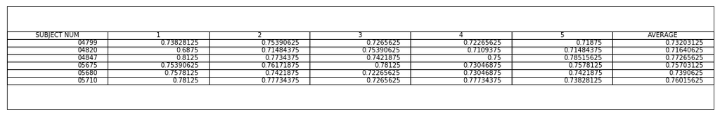

```python
plt.rcParams["figure.figsize"] = (20,3)
plt.rcParams.update({'font.size': 10})


fig, ax = plt.subplots()


ax.xaxis.set_visible(False)
ax.yaxis.set_visible(False)


clust_data = np.random.random((10,3))
collabel=("col 1", "col 2", "col 3")
#ax.table(cellText=df.values,colLabels=df.columns,loc='center')
ax.table(cellText=dataForPlot,colLabels=labelsForPlot,loc='center')
plt.show()
```

Generate Info for each trial.

Extract sentence data and picture data where cond is 2 or 3 for subject 04799.

First stimulus is shown for 4 seconds and 1 image is taken every 500 ms.

```python
info04799 = []
sentence04799 = []
picture04799 = []
rawData04799 = mat04799['data']
for i in range(mata04799['ntrials']):
    infoOfGivenTrial = dataExtract_latest.getInfoFromList(mat04799,i)
    info04799.append(infoOfGivenTrial)
    if infoOfGivenTrial['cond'] == 2 or infoOfGivenTrial['cond'] == 3:
        if infoOfGivenTrial['firstStimulus'] == 'P':
            for j in range(8):
                picture04799.append(rawData04799[i][0][j])
            for j in range(16,24):
                sentence04799.append(rawData04799[i][0][j])
        elif infoOfGivenTrial['firstStimulus'] == 'S':
            for j in range(8):
                sentence04799.append(rawData04799[i][0][j])
            for j in range(16,24):
                picture04799.append(rawData04799[i][0][j])
```

make data variable to store all the data and label variable for storing labels

label 1 for sentence

label 0 for picture

```python
data04799 = sentence04799+picture04799
```

```python
labels04799 = [1]*len(sentence04799) + [0]*len(picture04799)
```

```python
accuracy04799 = []
for i in range(5):
    x_train04799, x_test04799 , y_train04799, y_test04799 = train_test_split(data04799,labels04799,test_size = 0.2)
    clf = svm.SVC(kernel='linear')
    clf.fit(x_train04799, y_train04799)
    y_pred04799 = clf.predict(x_test04799)
    accuracy = metrics.accuracy_score(y_test04799, y_pred04799)
    accuracy04799.append(accuracy)
```

For Subject 04820

```python
info04820 = []
sentence04820 = []
picture04820 = []
rawData04820 = mat04820['data']
for i in range(mata04820['ntrials']):
    infoOfGivenTrial = dataExtract_latest.getInfoFromList(mat04820,i)
    info04820.append(infoOfGivenTrial)
    if infoOfGivenTrial['cond'] == 2 or infoOfGivenTrial['cond'] == 3:
        if infoOfGivenTrial['firstStimulus'] == 'P':
            for j in range(8):
                picture04820.append(rawData04820[i][0][j])
            for j in range(16,23):
                sentence04820.append(rawData04820[i][0][j])
        elif infoOfGivenTrial['firstStimulus'] == 'S':
            for j in range(8):
                sentence04820.append(rawData04820[i][0][j])
            for j in range(16,23):
                picture04820.append(rawData04820[i][0][j])
```

```python
data04820 = sentence04820+picture04820
labels04820 = [1]*len(sentence04820) + [0]*len(picture04820)
accuracy04820 = []
for i in range(5):
    x_train04820, x_test04820 , y_train04820, y_test04820 = train_test_split(data04820,labels04820,test_size = 0.2)
    clf = svm.SVC(kernel='linear')
    clf.fit(x_train04820, y_train04820)
    y_pred04820 = clf.predict(x_test04820)
    accuracy = metrics.accuracy_score(y_test04820, y_pred04820)
    accuracy04820.append(accuracy)
```

For Subject 04847

```python
info04847 = []
sentence04847 = []
picture04847 = []
rawData04847 = mat04847['data']
for i in range(mata04847['ntrials']):
    infoOfGivenTrial = dataExtract_latest.getInfoFromList(mat04847,i)
    info04847.append(infoOfGivenTrial)
    if infoOfGivenTrial['cond'] == 2 or infoOfGivenTrial['cond'] == 3:
        if infoOfGivenTrial['firstStimulus'] == 'P':
            for j in range(8):
                picture04847.append(rawData04847[i][0][j])
            for j in range(16,24):
                sentence04847.append(rawData04847[i][0][j])
        elif infoOfGivenTrial['firstStimulus'] == 'S':
            for j in range(8):
                sentence04847.append(rawData04847[i][0][j])
            for j in range(16,24):
                picture04847.append(rawData04847[i][0][j])
data04847 = sentence04847+picture04847
labels04847 = [1]*len(sentence04847) + [0]*len(picture04847)
accuracy04847 = []
for i in range(5):
    x_train04847, x_test04847 , y_train04847, y_test04847 = train_test_split(data04847,labels04847,test_size = 0.2)
    clf = svm.SVC(kernel='linear')
    clf.fit(x_train04847, y_train04847)
    y_pred04847 = clf.predict(x_test04847)
    accuracy = metrics.accuracy_score(y_test04847, y_pred04847)
    accuracy04847.append(accuracy)
```

For Subject 05675

```python
info05675 = []
sentence05675 = []
picture05675 = []
rawData05675 = mat05675['data']
for i in range(mata05675['ntrials']):
    infoOfGivenTrial = dataExtract_latest.getInfoFromList(mat05675,i)
    info05675.append(infoOfGivenTrial)
    if infoOfGivenTrial['cond'] == 2 or infoOfGivenTrial['cond'] == 3:
        if infoOfGivenTrial['firstStimulus'] == 'P':
            for j in range(16):
                picture05675.append(rawData05675[i][0][j])
            for j in range(16,32):
                sentence05675.append(rawData05675[i][0][j])
        elif infoOfGivenTrial['firstStimulus'] == 'S':
            for j in range(16):
                sentence05675.append(rawData05675[i][0][j])
            for j in range(16,32):
                picture05675.append(rawData05675[i][0][j])
data05675 = sentence05675+picture05675
labels05675 = [1]*len(sentence05675) + [0]*len(picture05675)
accuracy05675 = []
for i in range(5):
    x_train05675, x_test05675 , y_train05675, y_test05675 = train_test_split(data05675,labels05675,test_size = 0.2)
    clf = svm.SVC(kernel='linear')
    clf.fit(x_train05675, y_train05675)
    y_pred05675 = clf.predict(x_test05675)
    accuracy = metrics.accuracy_score(y_test05675, y_pred05675)
    accuracy05675.append(accuracy)
```

For Subject 05680

```python
info05680 = []
sentence05680 = []
picture05680 = []
rawData05680 = mat05680['data']
for i in range(mata05680['ntrials']):
    infoOfGivenTrial = dataExtract_latest.getInfoFromList(mat05680,i)
    info05680.append(infoOfGivenTrial)
    if infoOfGivenTrial['cond'] == 2 or infoOfGivenTrial['cond'] == 3:
        if infoOfGivenTrial['firstStimulus'] == 'P':
            for j in range(16):
                picture05680.append(rawData05680[i][0][j])
            for j in range(16,32):
                sentence05680.append(rawData05680[i][0][j])
        elif infoOfGivenTrial['firstStimulus'] == 'S':
            for j in range(16):
                sentence05680.append(rawData05680[i][0][j])
            for j in range(16,32):
                picture05680.append(rawData05680[i][0][j])
data05680 = sentence05680+picture05680
labels05680 = [1]*len(sentence05680) + [0]*len(picture05680)
accuracy05680 = []
for i in range(5):
    x_train05680, x_test05680 , y_train05680, y_test05680 = train_test_split(data05680,labels05680,test_size = 0.2)
    clf = svm.SVC(kernel='linear')
    clf.fit(x_train05680, y_train05680)
    y_pred05680 = clf.predict(x_test05680)
    accuracy = metrics.accuracy_score(y_test05680, y_pred05680)
    accuracy05680.append(accuracy)
```

For Subject 05710

```python
info05710 = []
sentence05710 = []
picture05710 = []
rawData05710 = mat05710['data']
for i in range(mata05710['ntrials']):
    infoOfGivenTrial = dataExtract_latest.getInfoFromList(mat05710,i)
    info05710.append(infoOfGivenTrial)
    if infoOfGivenTrial['cond'] == 2 or infoOfGivenTrial['cond'] == 3:
        if infoOfGivenTrial['firstStimulus'] == 'P':
            for j in range(16):
                picture05710.append(rawData05710[i][0][j])
            for j in range(16,32):
                sentence05710.append(rawData05710[i][0][j])
        elif infoOfGivenTrial['firstStimulus'] == 'S':
            for j in range(16):
                sentence05710.append(rawData05710[i][0][j])
            for j in range(16,32):
                picture05710.append(rawData05710[i][0][j])
data05710 = sentence05710+picture05710
labels05710 = [1]*len(sentence05710) + [0]*len(picture05710)
accuracy05710 = []
for i in range(5):
    x_train05710, x_test05710 , y_train05710, y_test05710 = train_test_split(data05710,labels05710,test_size = 0.2)
    clf = svm.SVC(kernel='linear')
    clf.fit(x_train05710, y_train05710)
    y_pred05710 = clf.predict(x_test05710)
    accuracy = metrics.accuracy_score(y_test05710, y_pred05710)
    accuracy05710.append(accuracy)
```

Format data for plotting

```python
append0 = list(subjects[0])
append1 = list(subjects[1])
append2 = list(subjects[2])
append3 = list(subjects[3])
append4 = list(subjects[4])
append5 = list(subjects[5])
append0.extend(accuracy04799)
append0.append(np.average(accuracy04799))
append1.extend(accuracy04820)
append1.append(np.average(accuracy04820))
append2.extend(accuracy04847)
append2.append(np.average(accuracy04847))
append3.extend(accuracy05675)
append3.append(np.average(accuracy05675))
append4.extend(accuracy05680)
append4.append(np.average(accuracy05680))
append5.extend(accuracy05710)
append5.append(np.average(accuracy05710))
dataForPlot=[]
dataForPlot.append(append0)
dataForPlot.append(append1)
dataForPlot.append(append2)
dataForPlot.append(append3)
dataForPlot.append(append4)
dataForPlot.append(append5)
labelsForPlot = ['SUBJECT NUM',1,2,3,4,5,'AVERAGE']
```

[figure not shown]

```python
plt.rcParams["figure.figsize"] = (20,3)
plt.rcParams.update({'font.size': 10})


fig, ax = plt.subplots()


ax.xaxis.set_visible(False)
ax.yaxis.set_visible(False)


clust_data = np.random.random((10,3))
collabel=("col 1", "col 2", "col 3")
#ax.table(cellText=df.values,colLabels=df.columns,loc='center')
ax.table(cellText=dataForPlot,colLabels=labelsForPlot,loc='center')
plt.show()
```